# Tenth Week: Principal Component Analysis and Factor Analysis

PCA Stock, image, …

Kimia Hamdieh (95109434)

[figure not shown]

> با استفاده از داده های OHLCV شرکت های تشکیل دهنده شاخص s&p500 و همچنین داده مربوط به شاخص های اقتصادی به سوالات زیر پاسخ دهید.

برای خواندن داده ی مربوط به سهام همه ی شرکت ها به این صورت عمل می کنیم. و در نهایت همه ی داده ی مربوط به شرکت ها را با اضافه کردن یک ستون نام شرکت، در دیتافریم stocks_df ذخیره می کنیم.

```r
constituents = read_csv("data/constituents.csv")
indexes = read_csv("data/indexes.csv")

files_list = list.files("data/stock_dfs")
stock = list()
for(i in 1:length(files_list)) {
  comp = read_csv(paste("data/stock_dfs", files_list[[i]], sep = "/"))
  comp = comp %>% mutate(company = str_replace(files_list[[i]], ".csv", ""))
  stock[[i]] = comp
}
stocks_df = bind_rows(stock)
```

۱. چه شرکتی رکورددار کسب بیشترین سود در بازه یکساله، دو ساله و پنج ساله می باشد؟ این سوال را برای بخش های مختلف مورد مطالعه قرار دهید و رکورددار را معرفی کنید. (برای این کار به ستون sector داده constituents مراجعه کنید.) برای هر دو قسمت نمودار سود ده شرکت و یا بخش برتر را رسم نمایید.

```r
stocks_df %>%
  mutate(year = format(Date,"%y") %>% as.numeric()) %>%
  mutate(month = format(Date,"%m") %>% as.numeric()) %>%
  mutate(time = year * 12 + month) %>%
  group_by(company, time) %>%
  slice(which.max(Date)) %>%
  select(Date, Open, Close, Volume, company, time) %>%
  ungroup() %>%
  arrange(company, time) %>%
  left_join(constituents, by = c("company" = "Symbol")) %>%
  select(-Name) -> monthly_stocks


monthly_stocks %>%
  group_by(company) %>%
  mutate(st_open = Open * Volume) %>%
  mutate(st_close = Close * Volume) %>%
  mutate(lagval = lag(st_open, 12)) %>%
  mutate(profit = st_close - lagval) -> prof_df

# most profit for each sector
prof_df %>%
  group_by(Sector) %>%
  slice(which.max(profit)) %>%
  drop_na() %>%
  select(Sector, company, profit)
```

```
## # A tibble: 11 x 3
## # Groups:   Sector [11]
##    Sector                     company      profit
##    <chr>                      <chr>         <dbl>
##  1 Consumer Discretionary     NKE      5998339840
##  2 Consumer Staples           MNST    12615747661
##  3 Energy                     VLO      8029258375
##  4 Financials                 GS       7435139969
##  5 Health Care                GILD    12997076184
##  6 Industrials                UNP      2994980959
##  7 Information Technology     AAPL    93708316641
##  8 Materials                  CF       3206957564
##  9 Real Estate                GGP      2724745956
## 10 Telecommunication Services T        2619802156
## 11 Utilities                  LNT      1958232956
```

```r
prof_df %>%
  arrange(desc(profit)) %>%
  head(20) %>%
  hchart(hcaes(x = Date, y = profit, color = company), type = "column") %>%
  hc_title(text = "Companies Stock Over One Year")
```

[interactive chart not shown]

```r
prof_df %>%
  group_by(company) %>%
  slice(which.max(profit)) %>%
  arrange(desc(profit)) %>%
  head(20) %>%
  hchart(hcaes(x = company, y = profit), type = "column") %>%
  hc_title(text = "Companies with most profits in a Year")
```

[interactive chart not shown]

```r
prof_df %>%
  group_by(company) %>%
  slice(which.max(profit)) %>%
  group_by(Sector) %>%
  summarise(profit = mean(profit)) %>%
  arrange(desc(profit)) %>%
  head(20) %>%
  hchart(hcaes(x = Sector, y = profit), type = "column") %>%
  hc_title(text = "Sectors with most profits in a Year")
```

[interactive chart not shown]

```r
monthly_stocks %>%
  group_by(company) %>%
  mutate(st_open = Open * Volume) %>%
  mutate(st_close = Close * Volume) %>%
  mutate(lagval = lag(st_open, 12 * 2)) %>%
  mutate(profit = st_close - lagval) -> prof_df

# most profit for each sector
prof_df %>%
  group_by(Sector) %>%
  slice(which.max(profit)) %>%
  drop_na() %>%
  select(Sector, company, profit)
```

```
## # A tibble: 11 x 3
## # Groups:   Sector [11]
##    Sector                     company       profit
##    <chr>                      <chr>          <dbl>
##  1 Consumer Discretionary     AMZN      6622193064
##  2 Consumer Staples           MNST     14164470102
##  3 Energy                     VLO       8265947602
##  4 Financials                 GS        8624897021
##  5 Health Care                GILD     13588852163
##  6 Industrials                UNP       3076683825
##  7 Information Technology     AAPL    103427265733
##  8 Materials                  CF        3827144386
##  9 Real Estate                GGP       2752495595
## 10 Telecommunication Services T         2645214597
## 11 Utilities                  LNT       1996334434
```

```r
prof_df %>%
  arrange(desc(profit)) %>%
  head(20) %>%
  hchart(hcaes(x = Date, y = profit, color = company), type = "column") %>%
  hc_title(text = "Companies Stock Over Two Years")
```

[interactive chart not shown]

```r
prof_df %>%
  group_by(company) %>%
  slice(which.max(profit)) %>%
  arrange(desc(profit)) %>%
  head(20) %>%
  hchart(hcaes(x = company, y = profit), type = "column") %>%
  hc_title(text = "Companies with most profits in Two Years")
```

[interactive chart not shown]

```r
prof_df %>%
  group_by(company) %>%
  slice(which.max(profit)) %>%
  group_by(Sector) %>%
  summarise(profit = mean(profit)) %>%
  arrange(desc(profit)) %>%
  head(20) %>%
  hchart(hcaes(x = Sector, y = profit), type = "column") %>%
  hc_title(text = "Sectors with most profits in Two Years")
```

[interactive chart not shown]

```r
monthly_stocks %>%
  group_by(company) %>%
  mutate(st_open = Open * Volume) %>%
  mutate(st_close = Close * Volume) %>%
  mutate(lagval = lag(st_open, 12 * 5)) %>%
  mutate(profit = st_close - lagval) -> prof_df

# most profit for each sector
prof_df %>%
  group_by(Sector) %>%
  slice(which.max(profit)) %>%
  drop_na() %>%
  select(Sector, company, profit)
```

```
## # A tibble: 11 x 3
## # Groups:   Sector [11]
##    Sector                     company       profit
##    <chr>                      <chr>          <dbl>
##  1 Consumer Discretionary     AMZN      7472599277
##  2 Consumer Staples           MNST     14395476006
##  3 Energy                     VLO       8364784147
##  4 Financials                 GS       10135691824
##  5 Health Care                BIIB      4213867563
##  6 Industrials                UNP       3672458259
##  7 Information Technology     AAPL    110023135072
##  8 Materials                  CF        4103217331
##  9 Real Estate                GGP       2737382282
## 10 Telecommunication Services T         3169569907
## 11 Utilities                  LNT       2012254910
```

```r
prof_df %>%
  arrange(desc(profit)) %>%
  head(20) %>%
  hchart(hcaes(x = Date, y = profit, color = company), type = "column") %>%
  hc_title(text = "Companies Stock Over Five Years")
```

[interactive chart not shown]

```r
prof_df %>%
  group_by(company) %>%
  slice(which.max(profit)) %>%
  arrange(desc(profit)) %>%
  head(20) %>%
  hchart(hcaes(x = company, y = profit), type = "column") %>%
  hc_title(text = "Companies with most profits in Five Years")
```

[interactive chart not shown]

```r
prof_df %>%
  group_by(company) %>%
  slice(which.max(profit)) %>%
  group_by(Sector) %>%
  summarise(profit = mean(profit)) %>%
  arrange(desc(profit)) %>%
  head(20) %>%
  hchart(hcaes(x = Sector, y = profit), type = "column") %>%
  hc_title(text = "Sectors with most profits in Five Years")
```

[interactive chart not shown]

برای به دست آوردن بیشترین سود شرکت ها در بازه های یک ساله، از ماه به عنوان کوچکترین واحد گذر زمان استفاده شده است. (می توان برای دقیق تر بود از روز نیز استفاده کرد ولی فرق چندانی ندارد.) به این صورت که معیار $year \times 12 + month$ برای گذر زمان استفاده شده است و در بازه های یک ساله، دو ساله و پنج ساله با این معیار، می توان بیشترین سود برای هر شرکت، بخش و … به دست آورد.

۲. یک اعتقاد خرافی می گوید خرید سهام در روز سیزدهم ماه زیان آور است. این گزاره را مورد ارزیابی قرار دهید.

```r
stocks_df %>%
  mutate(val = Close - Open) %>%
  filter(format(Date,"%d") %>% as.numeric() == 13) -> unlucky_df

wilcox.test(unlucky_df$val, mu = 0, alt = "greater")
```

```
##
##  Wilcoxon signed rank test with continuity correction
##
## data:  unlucky_df$val
## V = 1047100000, p-value = 0.455
## alternative hypothesis: true location is greater than 0
```

۳. رکورد بیشترین گردش مالی در تاریخ بورس برای چه روزی بوده است و چرا!!!

```r
stocks_df %>%
  group_by(Date) %>%
  summarize(vol = mean(Volume * `Adj Close`, na.omit = TRUE)) %>%
  slice(which.max(vol))
```

```
## # A tibble: 1 x 2
##   Date             vol
##   <date>         <dbl>
## 1 2015-08-24 505701203
```

۴. شاخص AAPL که نماد شرکت اپل است را در نظر بگیرید. با استفاده از رگرسیون خطی یک پیش کننده قیمت شروع (open price) بر اساس k روز قبل بسازید. بهترین انتخاب برای k چه مقداری است؟ دقت پیش بینی شما چقدر است؟

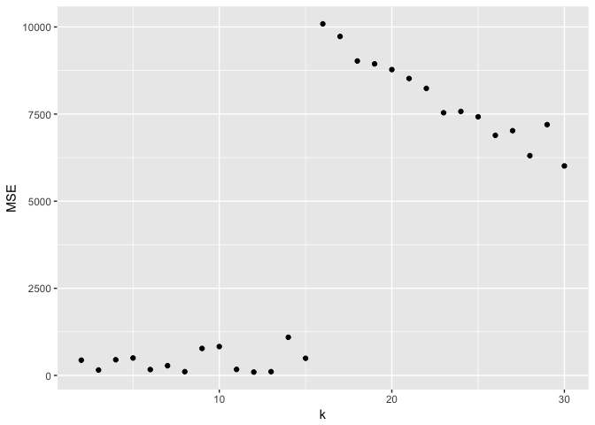

```r
stocks_df %>%
  filter(company == "AAPL") %>%
  select(Open, Date) -> apple_open

n = 30
mse = matrix(ncol = 2, nrow = n)
for(k in 2:n) {
  apple_open$Open %>% matrix(ncol = k + 1, byrow = TRUE) %>% as.data.frame() -> open_reg
  colnames(open_reg) = c(paste("day", 1:k), "final")
  htrain = as.h2o(open_reg)
  hglm = h2o.glm(y = "final", training_frame = htrain)
  mse[k, 1] = k
  mse[k, 2] = h2o.mse(hglm)
}
mse = mse %>% as.data.frame()
ggplot(mse, aes(x = V1, y = V2)) +
  xlab("k") + ylab("MSE") +
  geom_point()
```

```r
mse %>%
  filter(V1 != 0) %>%
  slice(which.min(V2))
```

```
## # A tibble: 1 x 2
##      V1    V2
##   <dbl> <dbl>
## 1  12.0  95.2
```

برای ساخت داده ی train باید به این صورت عمل کنیم که هر سطر داده، از $k$ روز تشکیل شده باشد و در نهایت ستون آخر یا $y$ مربوط به روز بعد از آن ها باشد. حال اگر همه ی روزها را در این جدول train قرار دهیم. (یعنی open همه ی روزها یک بار در سطر آخر باشد) داده هایمان وابسته به هم خواهند بود و بنابراین از روشی دیگر استفاده می کنیم. داده های Open روزهای مختلف را بسته به $k$ انتخاب شده، در ماتریسی $k+1$ ستونه به ترتیب می چینیم. در این حالت هر داده یکبار در train ظاهر شده است. سپس به ازای هر $k$ یک مدل خطی ساخته و سپس مدل با کمترین MSE را به دست می آوریم.

۵. بر روی داده های قیمت شروع شرکت ها الگوریتم pca را اعمال کنید. نمودار تجمعی درصد واریانس بیان شده در مولفه ها را رسم کنید. سه مولفه اول چند درصد از واریانس را تبیین می کند؟

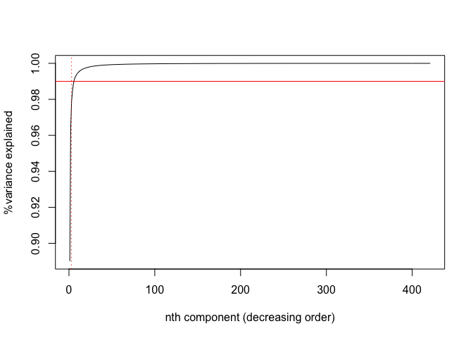

```r
stocks_df %>%
    select(Open, company, Date) %>%
    spread(company, Open) %>%
    select_if(function(col) sum(is.na(col)) < 500) -> open_df
open_df = na.omit(open_df, center = T)
open_dates = open_df$Date
pca_company = prcomp(open_df %>% select(-Date), center = TRUE)

plot(summary(pca_company)$importance[3,], type = "l",
     ylab = "%variance explained", xlab = "nth component (decreasing order)")
abline(h = 0.99, col="red"); abline(v = 3, col = "red", lty = 3)
```

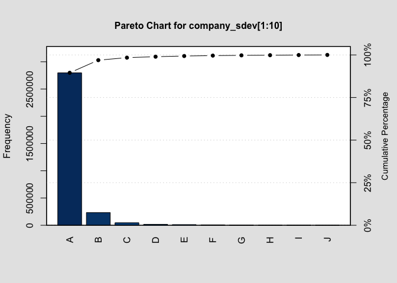

```
##
## Pareto chart analysis for company_sdev[1:10]
##        Frequency    Cum.Freq.   Percentage Cum.Percent.
##   A 2.797704e+06 2.797704e+06 8.950226e+01 8.950226e+01
##   B 2.321426e+05 3.029846e+06 7.426550e+00 9.692881e+01
##   C 4.601525e+04 3.075862e+06 1.472089e+00 9.840090e+01
##   D 1.753954e+04 3.093401e+06 5.611130e-01 9.896201e+01
##   E 1.221688e+04 3.105618e+06 3.908343e-01 9.935284e+01
##   F 7.944126e+03 3.113562e+06 2.541431e-01 9.960699e+01
##   G 4.488456e+03 3.118051e+06 1.435917e-01 9.975058e+01
##   H 3.069287e+03 3.121120e+06 9.819055e-02 9.984877e+01
##   I 2.927234e+03 3.124047e+06 9.364610e-02 9.994242e+01
##   J 1.799987e+03 3.125847e+06 5.758398e-02 1.000000e+02
```

```r
s = pca_company$sdev
company_sdev = s ^ 2;
qcc::pareto.chart(company_sdev[1:10])
```

```r
sdevs = as.data.frame(s)
colnames(sdevs) = c("s")
  sdevs %>%
  mutate(s = s ^ 2) %>%
  mutate(percent = cumsum(s) / sum(s)) %>%
  filter(row_number() == 3) %>%
  .$percent
```

```
## [1] 0.9785832
```

۶. برای هر نماد اطلاعات بخش مربوطه را از داده constituents استخراج نمایید. برای هر بخش میانگین روزانه قیمت شروع شرکت های آن را محاسبه کنید. سپس با استفاده از میانگین به دست آمده داده ایی با چند ستون که هر ستون یک بخش و هر سطر یک روز هست بسازید. داده مربوط را با داده شاخص های اقتصادی ادغام کنید. بر روی این داده pca بزنید و نمودار biplot آن را تفسیر کنید.

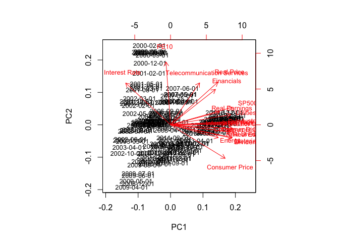

```r
stocks_df %>%
  left_join(constituents, by = c("company" = "Symbol")) %>%
  group_by(Sector, Date) %>%
  filter(!is.na(Sector)) %>%
  summarise(meanOpen = mean(Open, na.omit = TRUE)) %>%
  spread(Sector, meanOpen) %>%
  left_join(indexes, by = "Date") %>%
  drop_na() -> open_sector_df
dates = open_sector_df$Date %>% as.character()
open_sector_df %>% select(-Date) -> open_sector_df
rownames(open_sector_df) = dates
pca_sector = prcomp(open_sector_df, center = TRUE, scale. = TRUE)

biplot(pca_sector, cex = 0.8)
```

۷. روی همه اطلاعات (OHLCV) سهام اپل الگوریتم PCA را اعمال کنید. سپس از مولفه اول برای پیش بینی قیمت شروع سهام در روز آینده استفاده کنید. به سوالات سوال ۴ پاسخ دهید. آیا استفاده از مولفه اول نتیجه بهتری نسبت به داده open price برای پیش بینی قیمت دارد؟

[figure not shown]

```r
stocks_df %>%
  filter(company == "AAPL") %>%
  arrange(Date) %>%
  select(Date, Open, High, Low, Close, Volume) %>%
  drop_na() -> apple

pca_OHLCV = prcomp(apple %>% select(-Date), scale. = TRUE)
PC1 = pca_OHLCV$x[, 1]
apple = cbind(apple, PC1)

n = 30
mse = matrix(ncol = 2, nrow = n)
for(k in 2:n) {
  apple$Open %>% matrix(ncol = k + 1, byrow = TRUE) %>% as.data.frame() -> open_reg
  apple$PC1 %>% matrix(ncol = k + 1, byrow = TRUE) %>% as.data.frame() -> pc1_reg
  colnames(pc1_reg) = c(paste("day", 1:k), "final")
  colnames(open_reg) = c(paste("day", 1:k), "final")
  pc1_reg$final = open_reg$final
  htrain = as.h2o(pc1_reg)
  hglm = h2o.glm(y = "final", training_frame = htrain)
  mse[k, 1] = k
  mse[k, 2] = h2o.mse(hglm)
}

mse = mse %>% as.data.frame()
ggplot(mse, aes(x = V1, y = V2)) +
  xlab("k") + ylab("MSE") +
  geom_point()
```

```r
mse %>%
  filter(V1 != 0) %>%
  slice(which.min(V2))
```

```
## # A tibble: 1 x 2
##      V1    V2
##   <dbl> <dbl>
## 1  12.0  89.0
```

همان طور که مشاهده می شود مقدار خطای به دست آمده، کمتر از خطای قسمت ۴ است. چرا که PC1 در واقع کمیتی است که به جز open ، نمایان گر مقادیر (OHLCV) در $k$ روز قبلی نیز هست و با داشتن این اطلاعات تخمین ما از open روز بعد کمی بهتر خواهد بود.

۸. نمودار سود نسبی شاخص s&p500 را رسم کنید. آیا توزیع سود نرمال است؟(از داده indexes استفاده کنید.) با استفاده از ده مولفه اول سوال پنج آیا می توانید سود و ضرر شاخص s&p500 را برای روز آينده پیش بینی کنید؟ از یک مدل رگرسیون لاجستیک استفاده کنید. درصد خطای پیش بینی را به دست آورید.

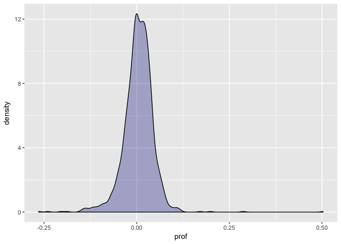

```r
indexes %>%
  select(Date, SP500) %>%
  mutate(prevsp = lag(SP500)) %>%
  mutate(prof = (SP500 - prevsp) / prevsp) %>%
  mutate(prof_f = ifelse(prof > 0, 1, 0)) -> sp_df

sp_df %>% ggplot(aes(prof)) +
  geom_density(fill = "dark blue", alpha = 0.3)
```

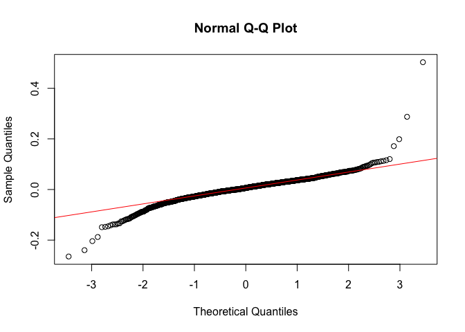

```r
qqnorm(sp_df$prof)
qqline(sp_df$prof, col = 2)
```

```r
pca_x = pca_company$x %>% as.data.frame() %>%
  select(PC1:PC10)
pca_x$Date = open_dates

sp_df %>%
  inner_join(pca_x, by = "Date") %>%
  select(prof_f, PC1:PC10) -> train_sp

htrain = as.h2o(train_sp)
hglm = h2o.glm(y = "prof_f", training_frame = htrain, family = "binomial", nfolds = 5)
# h2o.confusionMatrix(hglm)
summary(hglm)
```

```
## Model Details:
## ==============
##
## H2OBinomialModel: glm
## Model Key:  GLM_model_R_1525600638344_2578
## GLM Model: summary
##     family  link                               regularization
## 1 binomial logit Elastic Net (alpha = 0.5, lambda = 0.01721 )
##   number_of_predictors_total number_of_active_predictors
## 1                         10                           9
##   number_of_iterations training_frame
## 1                    5       train_sp
##
## H2OBinomialMetrics: glm
## ** Reported on training data. **
##
## MSE:  0.2094931
## RMSE:  0.4577042
## LogLoss:  0.6087921
## Mean Per-Class Error:  0.4316667
## AUC:  0.6626667
## Gini:  0.3253333
## R^2:  0.07648444
## Residual Deviance:  140.0222
## AIC:  160.0222
##
## Confusion Matrix (vertical: actual; across: predicted) for F1-optimal threshold:
##        0   1    Error     Rate
## 0      6  34 0.850000   =34/40
## 1      1  74 0.013333    =1/75
## Totals 7 108 0.304348  =35/115
##
## Maximum Metrics: Maximum metrics at their respective thresholds
##                         metric threshold    value idx
## 1                       max f1  0.506013 0.808743 107
## 2                       max f2  0.424937 0.907990 112
## 3                 max f0point5  0.627472 0.783476  68
## 4                 max accuracy  0.627472 0.704348  68
## 5                max precision  0.867594 1.000000   0
## 6                   max recall  0.424937 1.000000 112
```

[output cut: 87 more lines]

```
## Variable Importances: (Extract with `h2o.varimp`)
## =================================================
##
## Standardized Coefficient Magnitudes: standardized coefficient magnitudes
##    names coefficients sign
## 1   PC10     0.334303  POS
## 2    PC7     0.229710  POS
## 3    PC9     0.219231  POS
## 4    PC8     0.145203  POS
## 5    PC5     0.123408  NEG
## 6    PC6     0.085500  NEG
## 7    PC3     0.068146  POS
## 8    PC1     0.034427  POS
## 9    PC2     0.023254  POS
## 10   PC4     0.000000  POS
```

۹. عکسی که در ابتدای متن آمده را در نظر بگیرید. با استفاده از pca عکس را فشرده کنید. سپس نمودار حجم عکس فشرده بر حسب تعداد مولفه اصلی را رسم کنید. بهترین انتخاب برای انتخاب تعداد مولفه ها در جهت فشرده سازی چه عددی است؟

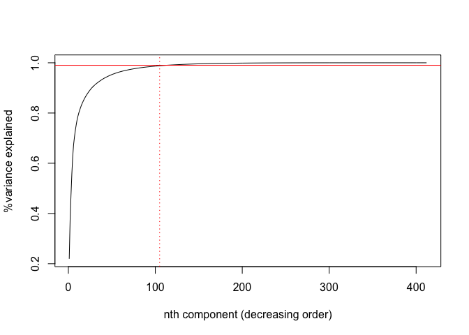

```r
library(EBImage)
library(jpeg)

pic = flip(readImage("images/stock.jpg"))

r.weigth = imageData(pic)[,,1]
g.weigth = imageData(pic)[,,2]
b.weigth = imageData(pic)[,,3]
img = r.weigth * imageData(pic)[,,1] +
      g.weigth * imageData(pic)[,,2] +
      b.weigth * imageData(pic)[,,3]

pca.img = prcomp(img, scale. = T)

plot(summary(pca.img)$importance[3, ], type = "l",
  ylab = "%variance explained", xlab = "nth component (decreasing order)")

abline(h = 0.99, col = "red")
abline(v = 105, col = "red", lty = 3)
```

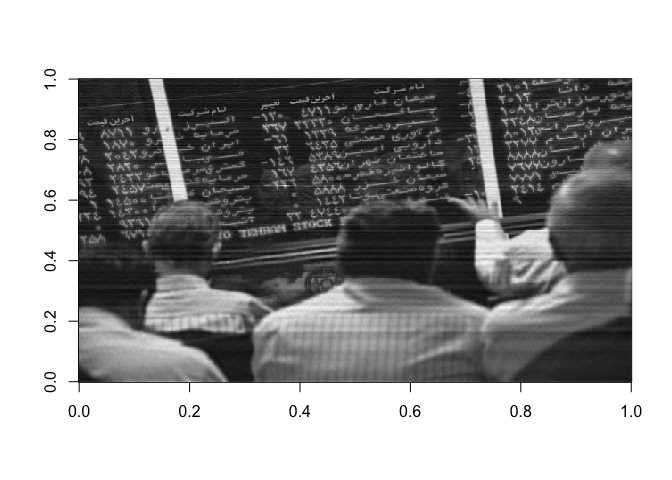

```r
chosen.components = 1:105
feature.vector = pca.img$rotation[, chosen.components]
compact.data = t(feature.vector) %*% t(img)
approx.img = t(feature.vector %*% compact.data)

image(approx.img, col = grey(seq(0, 1, length = 256)))
```

```r
writeJPEG(approx.img, "p.jpg")
(file.info("p.jpg")$size / 1000) / (file.info("images/stock.jpg")$size / 1000) * 100
```

```
## [1] 80.78297
```

```r
save.size = object.size(compact.data) + object.size(feature.vector)
save.size
```

```
## 879456 bytes
```

۱۰. پنج ایده جالبی که روی داده های مالی بالا می توانستیم پیاده کنیم را بیان کنید. (ایده کافی است نیازی به محاسبه بر روی داده نیست.)

1. بررسی تغییرات سهام یک شرکت از روی (OHLCV) با استفاده از مولفه ی اول PCA روی و در نهایت پیش بینی سهام شرکتی که شرایط مشابه دارد.
2. بررسی تغییر سهام های sector های مختلف و پیش بینی متوسط سهام های هر بخش با توجه به مقادیر قبلی آن.
3. پیش بینی این که آیا یک افت سهام نوسانی است و یا این که ادامه خواهد داشت با استفاده از مدل لاجستیک.
4. بررسی تغییرات سهام بخش های مختلف در طول زمان. و تغییر گرایش مردم به آن ها. (شرکت های بزرگ در هر دوران از کدام بخش بوده اند؟)
5. پیدا مردن روزهایی که نوسانات سهام در آن بسیار زیاد بوده (با استفاده از high و low در هر روز) و در نهایت تشخیص روزهای پرنوسان از روی اطلاعات روزهای قبل با استفاده از pca